# 6 Geographical data computing

This chapter is about re projecting geographical layers, adding external or personal layers as the flow map background, and their customization.

**Flow mapping tips**

1. Importing flow data (links/nodes)
2. Processing flow data (indicators calculation, …)
3. **Geographical data computing (layering, …)**
4. Statistical data computing (filtering, …)
5. Cartographic symbolization (designing arrows, …)
6. Map cosmetics (naming, …)
7. Export

## 6.1 (re)Projecting layers

The cartographic projection of the layers can be changed, by choosing one of the proposed formulas in the projection menu.

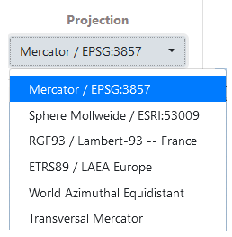

> Example: several projections applied on the RICardo world trade map

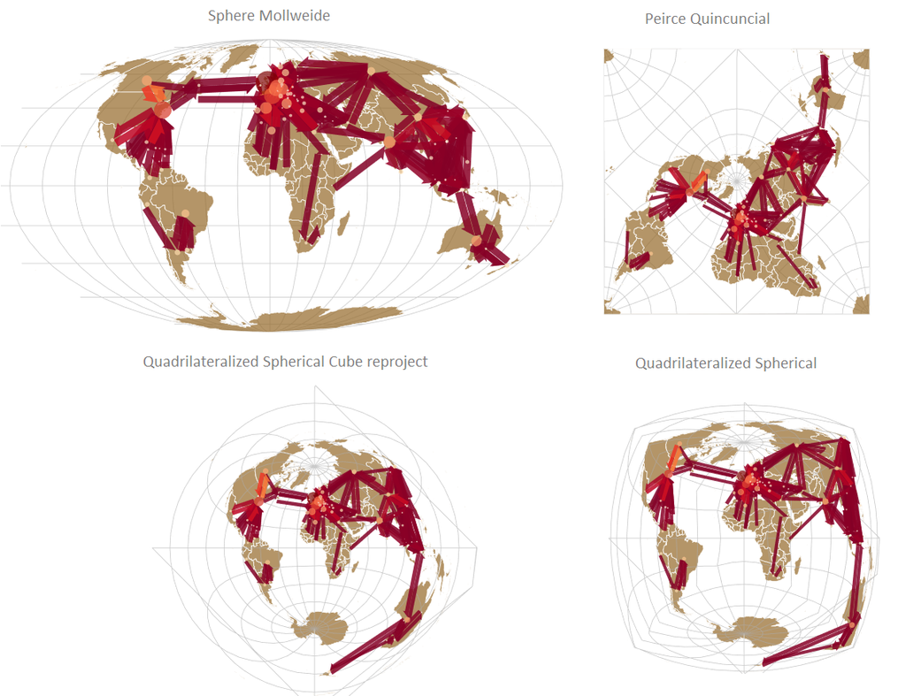

## 6.2 Geographical layers

The management of the map background is related to the geographic information. It can be accessed via the Layer button, and is composed of three sub-sections.

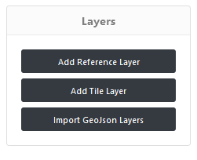

### 6.2.1 Add reference layer

Add reference layers consists in calling a remote geographic information layer from Natural Earth data features, to contextualize the flowmap.

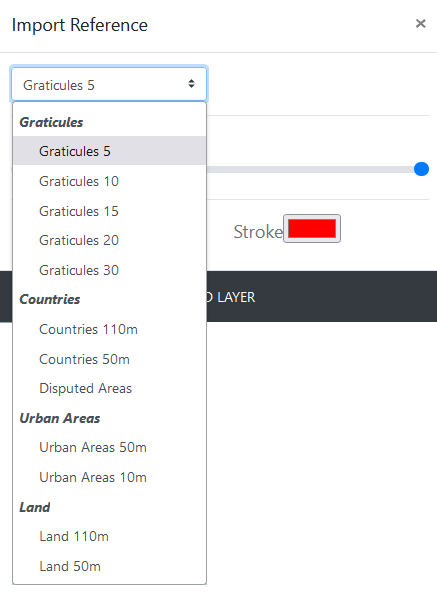

Selected reference layers are:

- geographical graticules are grids at 5, 10, 15, 20 and 30° intervals. Includes WGS84 bounding box. [See details…](https://www.naturalearthdata.com/downloads/50m-physical-vectors/50m-graticules/)

  > Example: Add graticule layer 20° interval

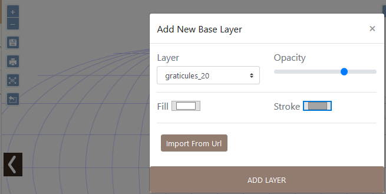

- world’s countries divisions at spatial resolutions of 110 meters or 50 meters, and the disputed areas. [See details…](https://www.naturalearthdata.com/downloads/10m-cultural-vectors/10m-admin-0-countries/)

> Example: countries

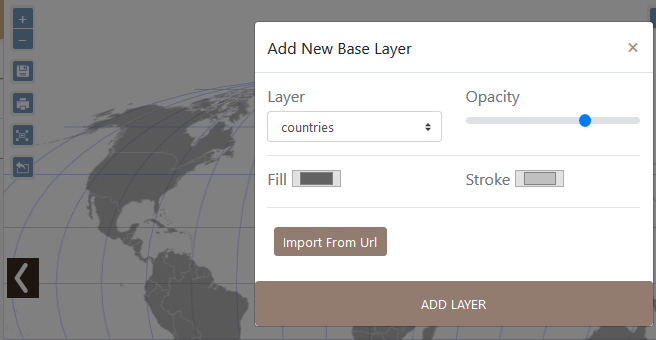

- world urban areas (of dense human habitations) coverage derived from MODIS satellite, at spatial resolutions of 50 meters or 10 meters. [See details…](https://www.naturalearthdata.com/downloads/50m-cultural-vectors/50m-urban-areas/)
- world landscape based on lands including major islands. [See details…](https://www.naturalearthdata.com/downloads/10m-physical-vectors/10m-land/)

For all these layers, their fill and stroke can be defined by picking colors, then click on Add layer button.

### 6.2.2 Add tile layer

The Base type of tiles layers come from Open Street Map (OSM) [tile server](https://wiki.openstreetmap.org/wiki/Tile_servers), CARTO DB and [ESRI tile server](https://enterprise.arcgis.com/fr/server/latest/publish-services/linux/vector-tile-services.htm).

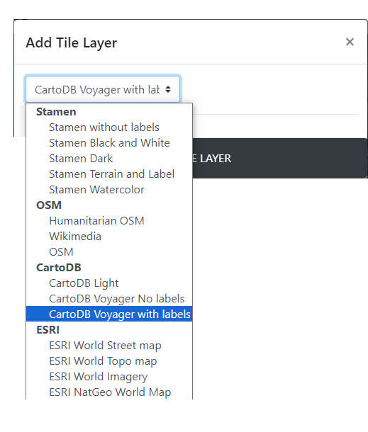

### 6.2.3 Add Geojson layer

Import Geojson is to load a personal vector layer.

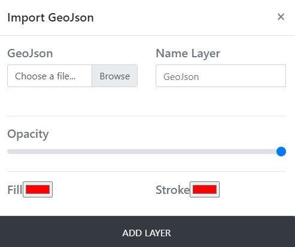